# S-R Compatibility Task - Exploratory Analysis

Milan Ewert, Tim Bax, Niklas Bub, Özge Özenoglu

mewert@uos.de, tbax@uos.de, nbub@uos.de, ooezenoglu@uos.de

July 28, 2020

# Preliminaries

## Load libraries

```r
library(tidyverse)
library(brms)
library(tidybayes)
library(bayesplot)
# devtools::install_github('michael-franke/bayes_mixed_regression_tutorial/faintr',build_vignettes = TRUE)
library(faintr)

options(mc.cores = parallel::detectCores())

color_palette = c("#E69F00", "#56B4E9", "#009E73", "#F0E442", "#0072B2", "#D55E00", "#CC79A7", "#000000")

scale_colour_discrete <- function(...) {
  scale_colour_manual(..., values = color_palette)
}

scale_fill_discrete <- function(...) {
   scale_fill_manual(..., values = color_palette)
}
```

## Load raw data

```r
raw_data <- read.csv('https://raw.githubusercontent.com/ooezenoglu/XPlab-2020-SR-Compatibility/master/data/02_main/01-raw-data-main.csv')

glimpse(raw_data)
```

```
## Rows: 7,650
## Columns: 22
## $ submission_id <int> 1947, 1947, 1947, 1947, 1947, 1947, 1947, 1947, 1947,...
## $ RT            <int> 1249, 2415, 723, 721, 664, 517, 386, 641, 377, 382, 6...
## $ age           <int> 21, 21, 21, 21, 21, 21, 21, 21, 21, 21, 21, 21, 21, 2...
## $ comments      <chr> "", "", "", "", "", "", "", "", "", "", "", "", "", "...
## $ condition     <chr> "incompatible", "incompatible", "incompatible", "inco...
## $ correctness   <chr> "incorrect", "timeout", "correct", "correct", "correc...
## $ education     <chr> "right", "right", "right", "right", "right", "right",...
## $ endTime       <dbl> 1.595887e+12, 1.595887e+12, 1.595887e+12, 1.595887e+1...
## $ expected      <chr> "big", "big", "big", "big", "small", "small", "small"...
## $ experiment_id <int> 155, 155, 155, 155, 155, 155, 155, 155, 155, 155, 155...
## $ gender        <chr> "male", "male", "male", "male", "male", "male", "male...
## $ key_pressed   <chr> "p", "q", "q", "q", "p", "p", "p", "p", "p", "q", "q"...
## $ languages     <chr> "german", "german", "german", "german", "german", "ge...
## $ left          <chr> "big", "big", "big", "big", "big", "big", "big", "big...
## $ order         <chr> "compatible_second", "compatible_second", "compatible...
## $ picture       <chr> "materials/large-stimulus.png", "materials/large-stim...
## $ right         <chr> "small", "small", "small", "small", "small", "small",...
## $ startDate     <chr> "Mon Jul 27 2020 23:48:13 GMT+0200 (MitteleuropÃ¤isch...
## $ startTime     <dbl> 1.595886e+12, 1.595886e+12, 1.595886e+12, 1.595886e+1...
## $ timeSpent     <dbl> 9.075767, 9.075767, 9.075767, 9.075767, 9.075767, 9.0...
## $ trial_number  <int> 1, 2, 3, 4, 5, 6, 7, 8, 9, 10, 1, 2, 3, 4, 5, 6, 7, 8...
## $ trial_type    <chr> "practice", "practice", "practice", "practice", "prac...
```

# Data Wrangling

```r
d <- raw_data %>%
  # rename column 'education' to 'handedness'
  rename(handedness = education) %>%
  # discard columns not needed for analysis
  select(-picture, -startDate, -startTime, -endTime, -timeSpent, -comments, -gender, -languages)
```

We exclude every individual trial with reaction times below 100 ms and above 1500 ms:

```r
d <- d %>%
  mutate(
    outlier = case_when(RT < 100 ~ TRUE,
                        RT > 1500 ~ TRUE,
                        TRUE ~ FALSE)
  )
```

There are 199 outliers to be excluded.

```r
d <- d %>%
    filter(outlier == FALSE)
```

We exclude all data from practice trials:

```r
d <- d %>%
  filter(trial_type == "main")
```

We only look at correct responses:

```r
d <- d %>%
  filter(correctness == "correct")
```

Given the variables `condition` and `expected`, we create a new variable `correct_response` that will serve as a covariate.

```r
d <- d %>%
mutate(
  # if the condition is 'compatible' and the square is 'big', store the value 'right' in correct_response
  correct_response = ifelse(condition == "compatible" & expected == "big", "right",
                            # if the condition is 'incompatible' and the square is 'small', store the value 'right' in correct_response;
                            # else: store the value 'left' in correct_response (case: compatible, small; incompatible, big)
                            ifelse(condition == "incompatible" & expected == "small", "right", "left"))
)
```

We rename the “I am able to use both hands equally well”-value to “both” for `handedness`

```r
d <- d %>%
  mutate(handedness = ifelse(handedness == "right", "right",
                              ifelse(handedness == "left", "left", "both")))
```

```r
# peek at the first six rows
head(d)
```

```
##   submission_id  RT age    condition correctness handedness expected
## 1          1947 650  21 incompatible     correct      right      big
## 2          1947 478  21 incompatible     correct      right      big
## 3          1947 444  21 incompatible     correct      right    small
## 4          1947 471  21 incompatible     correct      right      big
## 5          1947 485  21 incompatible     correct      right    small
## 6          1947 425  21 incompatible     correct      right      big
##   experiment_id key_pressed left             order right trial_number
## 1           155           q  big compatible_second small            1
## 2           155           q  big compatible_second small            2
## 3           155           p  big compatible_second small            3
## 4           155           q  big compatible_second small            4
## 5           155           p  big compatible_second small            5
## 6           155           q  big compatible_second small            6
##   trial_type outlier correct_response
## 1       main   FALSE             left
## 2       main   FALSE             left
## 3       main   FALSE            right
## 4       main   FALSE             left
## 5       main   FALSE            right
## 6       main   FALSE             left
```

# Exploratory Analysis

```r
d_agg_expl <- d %>%
  # look at each level of 'condition', 'correct_response' and 'handedness'
  group_by(condition, correct_response, handedness) %>%
  # get the mean and standard deviation of the reaction time
  summarize(mean_RT = mean(RT),
            sd_RT = sd(RT))

d_agg_expl
```

```
## # A tibble: 12 x 5
## # Groups:   condition, correct_response [4]
##    condition    correct_response handedness mean_RT sd_RT
##    <chr>        <chr>            <chr>        <dbl> <dbl>
##  1 compatible   left             both          537.  90.4
##  2 compatible   left             left          541. 155.
##  3 compatible   left             right         534. 142.
##  4 compatible   right            both          560. 106.
##  5 compatible   right            left          532. 148.
##  6 compatible   right            right         529. 149.
##  7 incompatible left             both          538. 101.
##  8 incompatible left             left          559. 175.
##  9 incompatible left             right         565. 181.
## 10 incompatible right            both          537.  79.6
## 11 incompatible right            left          574. 170.
## 12 incompatible right            right         563. 176.
```

```r
d_agg_participant_expl <- d %>%
  # look at each level of 'condition', 'correct_response' and 'handedness' for each participant
  group_by(condition, correct_response, submission_id, handedness) %>%
  # get the mean and standard deviation of the reaction time
  summarize(mean_RT = mean(RT),
            sd_RT = sd(RT))

head(d_agg_participant_expl)
```

```
## # A tibble: 6 x 6
## # Groups:   condition, correct_response, submission_id [6]
##   condition  correct_response submission_id handedness mean_RT sd_RT
##   <chr>      <chr>                    <int> <chr>        <dbl> <dbl>
## 1 compatible left                      1652 right         630. 143.
## 2 compatible left                      1655 left          531. 129.
## 3 compatible left                      1656 right         639. 161.
## 4 compatible left                      1657 right         465.  81.6
## 5 compatible left                      1659 right         497.  88.5
## 6 compatible left                      1660 right         406.  31.9
```

```r
handedness_table <- d %>%
  select(submission_id, handedness) %>%
  group_by(submission_id, handedness) %>%
  summarize()

# check counts within the 'handedness' variable
handedness_counts <- tibble(
  handedness = c("right", "left", "both", "no answer"),
  counts = c(sum(handedness_table$handedness=="right"),
             sum(handedness_table$handedness=="left"),
             sum(handedness_table$handedness=="both"),
             sum(handedness_table$handedness=="")))

handedness_counts
```

```
## # A tibble: 4 x 2
##   handedness counts
##   <chr>       <int>
## 1 right          44
## 2 left            6
## 3 both            1
## 4 no answer       0
```

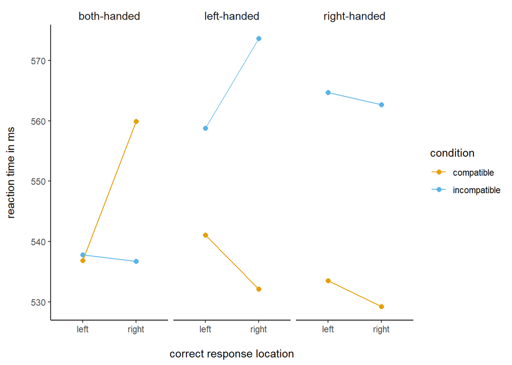

```r
ggplot(d_agg_expl, aes(x = correct_response, y = mean_RT, color = condition)) +
  geom_point(size = 2) +
  geom_line(aes(group = condition)) +
  facet_wrap(.~handedness,
             labeller = labeller(handedness = c("left" = "left-handed", "right" = "right-handed", "both" = "both-handed"))) +
  xlab("\ncorrect response location") +
  ylab("reaction time in ms\n") +
  theme_classic() +
  theme(strip.background = element_blank(), strip.text = element_text(size = 11))
```

## Model Specification

In case that there are left-handed participants, we fit a Bayesian hierarchical linear model with variate `RT` (reaction time), covariates `condition`, `correct_response`, `handedness`, as well as their three-way interaction. Furthermore, we specify by-participant random effects for the interaction of `condition` and `correct_response`. We use the default (flat) priors of the `brms` package for the effect coefficients.

```r
model_RE <- brm(
  formula = RT ~ condition * correct_response * handedness + # fixed effects
    (condition * correct_response||submission_id), # random effects
  data = d,
  iter = 3000,
  control = list(adapt_delta = 0.95, max_treedepth = 15),
  seed = 525
)
```

## Posterior estimates

```r
# print model output
model_RE
```

```
##  Family: gaussian
##   Links: mu = identity; sigma = identity
## Formula: RT ~ condition * correct_response * handedness + (condition * correct_response || submission_id)
##    Data: d (Number of observations: 5914)
## Samples: 4 chains, each with iter = 3000; warmup = 1500; thin = 1;
##          total post-warmup samples = 6000
##
## Group-Level Effects:
## ~submission_id (Number of levels: 51)
##                                                 Estimate Est.Error l-95% CI
## sd(Intercept)                                      94.13      9.99    76.65
## sd(conditionincompatible)                          61.22      7.29    48.29
## sd(correct_responseright)                          12.11      6.29     0.90
## sd(conditionincompatible:correct_responseright)    18.09      8.58     1.61
##                                                 u-95% CI Rhat Bulk_ESS Tail_ESS
## sd(Intercept)                                     115.86 1.00     1600     2691
## sd(conditionincompatible)                          77.04 1.00     3176     4454
## sd(correct_responseright)                          24.62 1.00     1780     2469
## sd(conditionincompatible:correct_responseright)    34.69 1.00     1507     2537
##
## Population-Level Effects:
##                                                             Estimate Est.Error
## Intercept                                                     535.94     95.42
## conditionincompatible                                           0.31     69.72
## correct_responseright                                          23.13     35.66
## handednessleft                                                  5.26    103.04
## handednessright                                                -2.98     96.61
## conditionincompatible:correct_responseright                   -24.37     50.48
## conditionincompatible:handednessleft                           16.67     75.81
## conditionincompatible:handednessright                          33.31     70.45
## correct_responseright:handednessleft                          -32.11     38.48
## correct_responseright:handednessright                         -27.39     36.04
## conditionincompatible:correct_responseright:handednessleft     48.56     54.39
## conditionincompatible:correct_responseright:handednessright    25.68     51.15
##                                                             l-95% CI u-95% CI
## Intercept                                                     348.23   721.06
## conditionincompatible                                        -137.91   138.96
## correct_responseright                                         -47.46    93.24
## handednessleft                                               -196.72   208.60
## handednessright                                              -191.76   187.37
```

[output cut: 26 more lines]

```
## conditionincompatible:correct_responseright                     4499
## conditionincompatible:handednessleft                            4393
## conditionincompatible:handednessright                           4258
## correct_responseright:handednessleft                            4510
## correct_responseright:handednessright                           4602
## conditionincompatible:correct_responseright:handednessleft      4325
## conditionincompatible:correct_responseright:handednessright     4604
##
## Family Specific Parameters:
##       Estimate Est.Error l-95% CI u-95% CI Rhat Bulk_ESS Tail_ESS
## sigma   125.14      1.15   122.91   127.42 1.00    14146     4700
##
## Samples were drawn using sampling(NUTS). For each parameter, Bulk_ESS
## and Tail_ESS are effective sample size measures, and Rhat is the potential
## scale reduction factor on split chains (at convergence, Rhat = 1).
```

```r
# take a look at the chosen priors by brms
prior_summary(model_RE)
```

```
##                       prior     class
## 1                                   b
## 2                                   b
## 3                                   b
## 4                                   b
## 5                                   b
## 6                                   b
## 7                                   b
## 8                                   b
## 9                                   b
## 10                                  b
## 11                                  b
## 12                                  b
## 13 student_t(3, 512, 114.2) Intercept
## 14   student_t(3, 0, 114.2)        sd
## 15                                 sd
## 16                                 sd
## 17                                 sd
## 18                                 sd
## 19                                 sd
## 20   student_t(3, 0, 114.2)     sigma
##                                                           coef         group
## 1
## 2                                        conditionincompatible
## 3                  conditionincompatible:correct_responseright
## 4   conditionincompatible:correct_responseright:handednessleft
## 5  conditionincompatible:correct_responseright:handednessright
## 6                         conditionincompatible:handednessleft
## 7                        conditionincompatible:handednessright
## 8                                        correct_responseright
## 9                         correct_responseright:handednessleft
## 10                       correct_responseright:handednessright
## 11                                              handednessleft
## 12                                             handednessright
## 13
## 14
## 15                                                             submission_id
## 16                                       conditionincompatible submission_id
## 17                 conditionincompatible:correct_responseright submission_id
## 18                                       correct_responseright submission_id
```

[output cut: 8 more lines]

```
## 6
## 7
## 8
## 9
## 10
## 11
## 12
## 13
## 14
## 15
## 16
## 17
## 18
## 19
## 20
```

## Hypothesis Testing

> Do right-handers respond faster in the compatible mapping condition than left-handers?

```r
compare_groups(
  model = model_RE,
  higher = list(condition = "compatible", handedness = "left"),
  lower = list(condition = "compatible", handedness = "right")
)
```

```
## Outcome of comparing groups:
##  * higher:  condition:compatible handedness:left
##  * lower:   condition:compatible handedness:right
## Mean 'higher - lower':  5.887
## 95% CI: [ -80.18 ; 87.61 ]
## P('higher - lower' > 0):  0.5603
```

> Do left-handers respond faster in the incompatible mapping condition than right-handers?

```r
compare_groups(
  model = model_RE,
  higher = list(condition = "incompatible", handedness = "right"),
  lower = list(condition = "incompatible", handedness = "left")
)
```

```
## Outcome of comparing groups:
##  * higher:  condition:incompatible handedness:right
##  * lower:   condition:incompatible handedness:left
## Mean 'higher - lower':  -0.6865
## 95% CI: [ -99.8 ; 97.21 ]
## P('higher - lower' > 0):  0.4968
```

> Do left-handers respond faster to left-responses than to right-responses?

```r
compare_groups(
  model = model_RE,
  higher = list(correct_response = "right", handedness = "left"),
  lower = list(correct_response = "left", handedness = "left")
)
```

```
## Outcome of comparing groups:
##  * higher:  correct_response:right handedness:left
##  * lower:   correct_response:left handedness:left
## Mean 'higher - lower':  3.108
## 95% CI: [ -20.12 ; 24.98 ]
## P('higher - lower' > 0):  0.6077
```

> Do right-handers respond faster to right-responses than to left-responses?

```r
compare_groups(
  model = model_RE,
  higher = list(correct_response = "left", handedness = "right"),
  lower = list(correct_response = "right", handedness = "right")
)
```

```
## Outcome of comparing groups:
##  * higher:  correct_response:left handedness:right
##  * lower:   correct_response:right handedness:right
## Mean 'higher - lower':  3.613
## 95% CI: [ -5.04 ; 11.98 ]
## P('higher - lower' > 0):  0.8052
```